# SalmonByRegion_NOAA

Lia Domke

10/9/2020

Interested in looking at salmon species by region

Steps:

1. Load Libraries
2. Load Data, fish by region
3. Filter by salmon only
4. Add back in zeros where no salmon caught by region

# Data

```r
seni <- read.csv("Data/noaa_region_seni.csv", stringsAsFactors = FALSE, header = TRUE)
seno <- read.csv("Data/noaa_region_seno.csv", stringsAsFactors = FALSE, header = TRUE)
seso <- read.csv("Data/noaa_region_seso.csv", stringsAsFactors = FALSE, header = TRUE)
sesi <- read.csv("Data/noaa_region_sesi.csv", stringsAsFactors = FALSE, header = TRUE)
```

District column

# Add zeros

# Visualize data

First lets look at total salmon abundances by species in different months

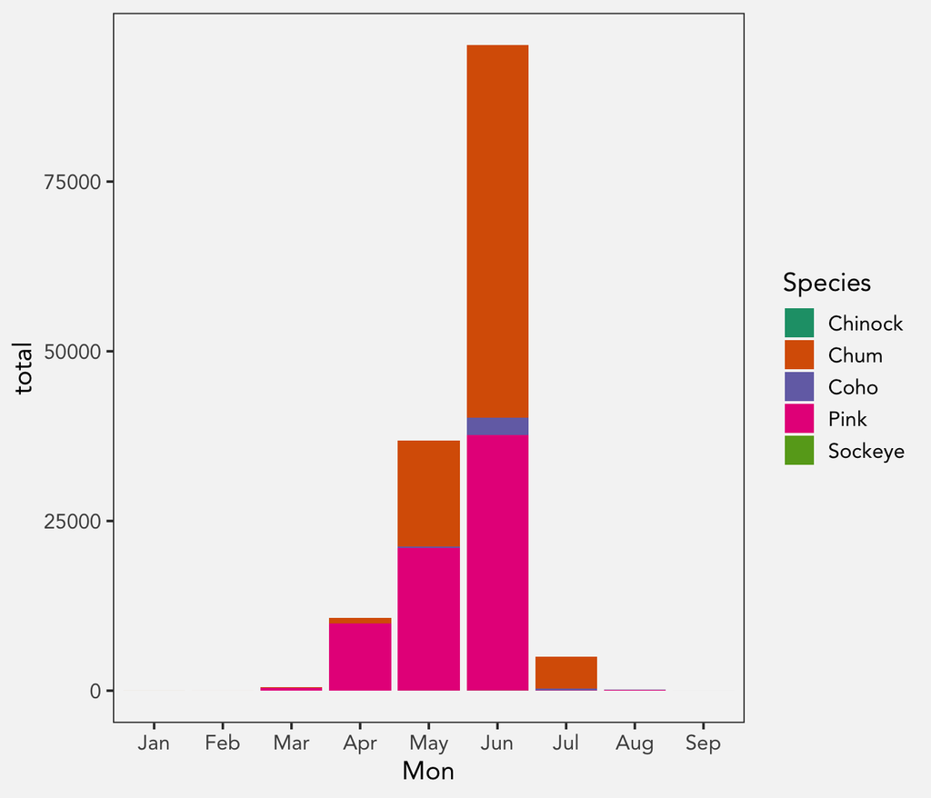

Figure 1: Total number of salmon caught by month overall in Southeast Alaska

Now, I divided total number of salmon caught by different districts in Southeast Alaska

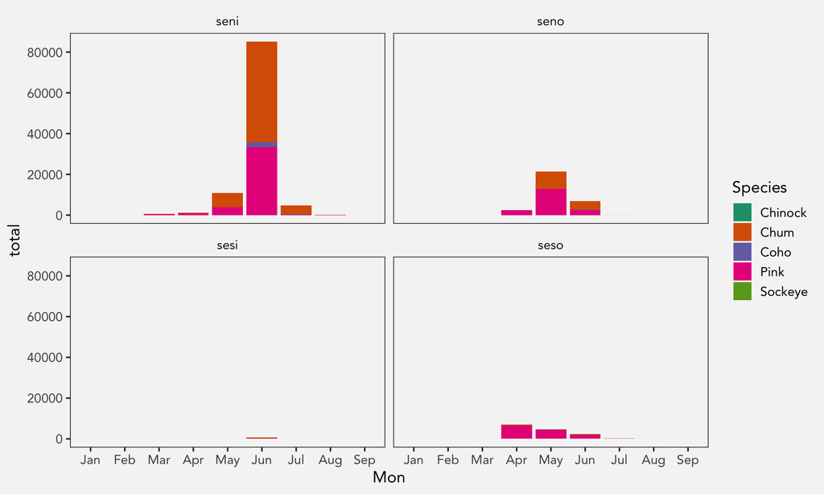

Figure 2: Total number of salmon caught by month and by district Southeast Alaska

Now lets go district by district and look at salmon numbers for each species.

In addition we’ll drop the months that we don’t care about. Including only April, May, June, and July

# First SENI (Southeast Northern Inside - Juneau/Lynn Canal Area)

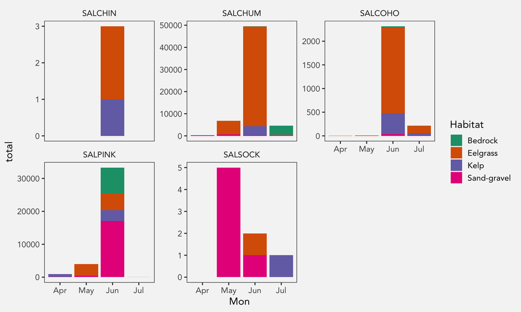

Figure 3: Number of salmon caught in summer months at four different habitat types in Southeast Northern Inside area with free y axis scale

# Next SENO (Southeast Northern Outside - Sitka/Outside Chichagof)

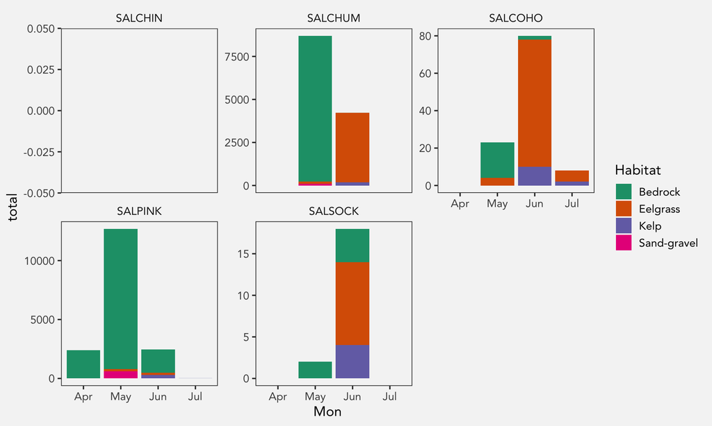

Figure 4: Number of salmon caught in summer months at four different habitat types in Southeast Northern Outside area with free y axis scale

# Next SESI (Southeast Southern Inside - Protected western POW/northern KTN up to southern Fredrick Sound)

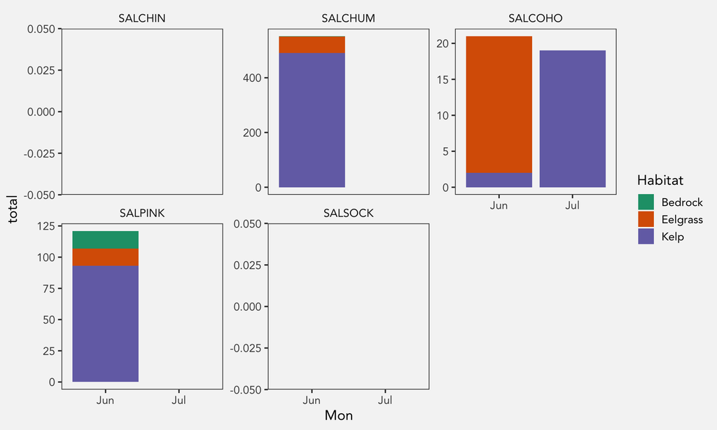

# Next SESO (Southeast Southern Outside - eastern POW/Exposed Ketchikan/Gravina Island area)

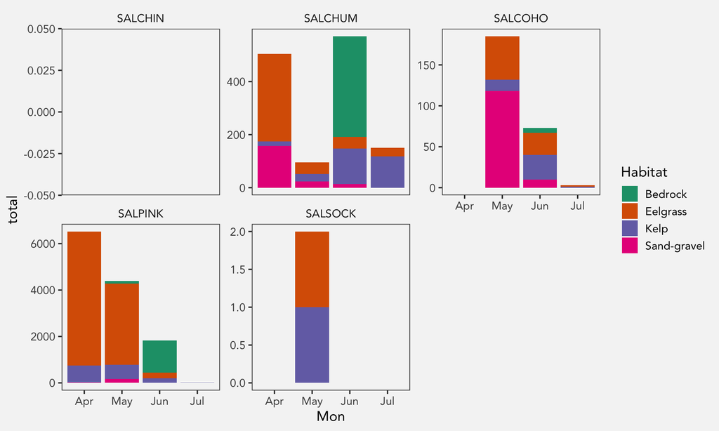

Figure 6: Number of salmon caught in summer months at four different habitat types in Southeast Southern Outside area with free y axis scale

# Combine pink salmon graphs

Lets look at only pink salmon for a second across each district

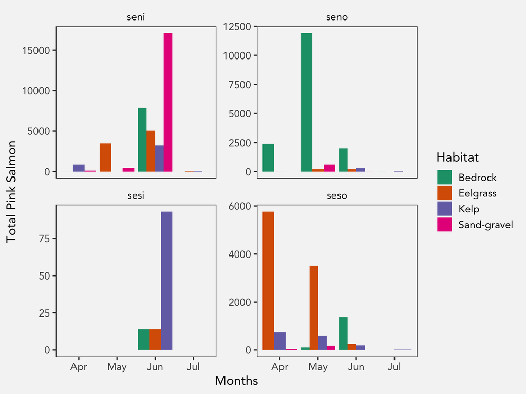

Figure 7: Number of pink salmon caught in summer months at four different habitat types with free y axis scales across four Southeastern districts excluding Yakutat

You’ll notice that the patterns of more pink salmon in bedrock we don’t necessarily see even in the SESO district (that we based the glm models on). The reason for this is that for SESO sites, I included **only sites I could pair**. Meaning I restricted the analysis to sites that were seined at the same time and that had vegetated and unvegetated habitats directly next to or closely adjacent.

# Chum salmon

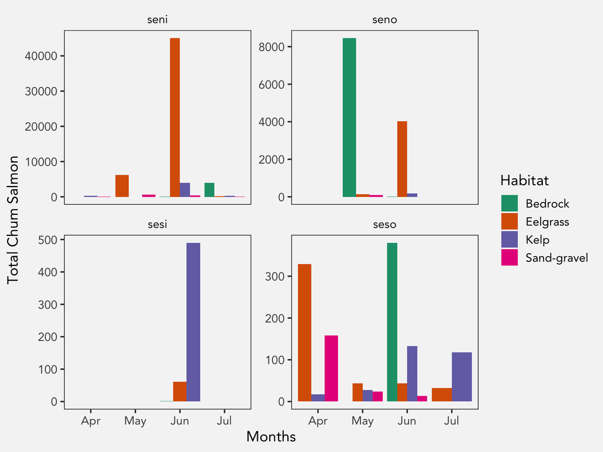

Figure 8: Number of chum salmon caught in summer months at four different habitat types with free y axis scales across four Southeastern districts excluding Yakutat

# Coho salmon

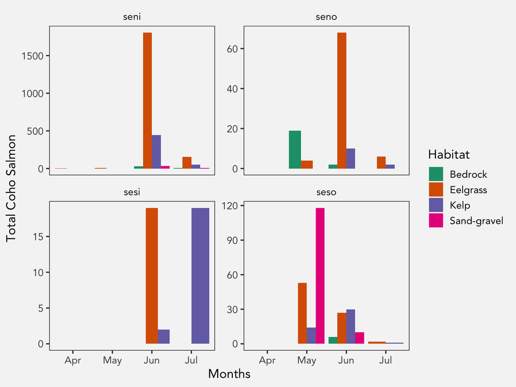

Figure 9: Number of coho salmon caught in summer months at four different habitat types with free y axis scales across four Southeastern districts excluding Yakutat

Okay so clearly there’s just a ton of variability in total salmon abundances. Lets look in average numbers because there definitely were habitats that were seined more than others.

# Average salmon caught by hab

## Pink salmon

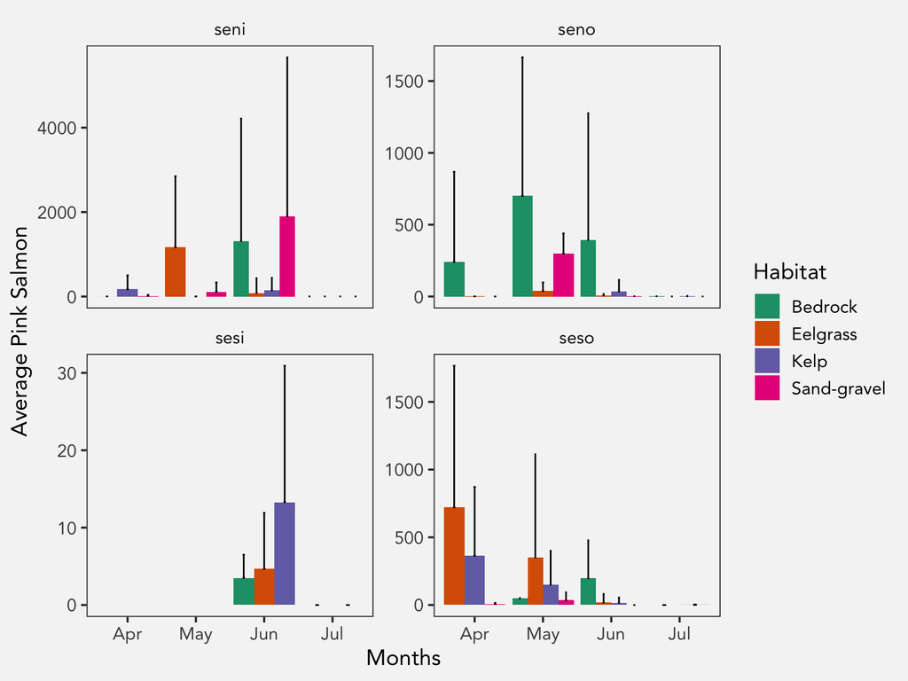

Figure 10: Average (+sd) number of pink salmon caught in summer months at four different habitat types with free y axis scales across four Southeastern districts excluding Yakutat

Only included the positive standard deviation in 10 because it got real messy/ugly with the negative standard deviation. Basically, by visual assesment there doesn’t look like true difference between the habitats. Remember y axis is free.

## Chum salmon

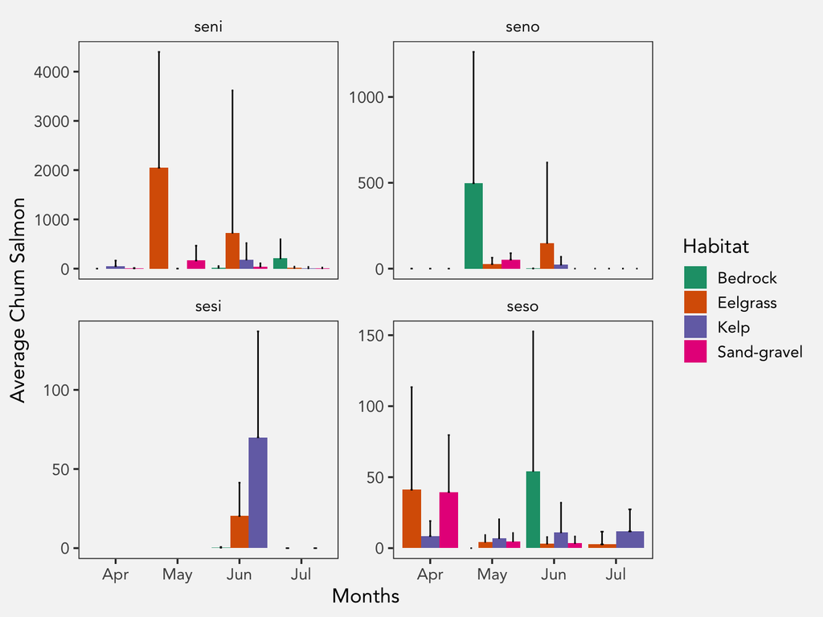

Figure 11: Average (+sd) number of chum salmon caught in summer months at four different habitat types with free y axis scales across four Southeastern districts excluding Yakutat

# Veg/Unveg

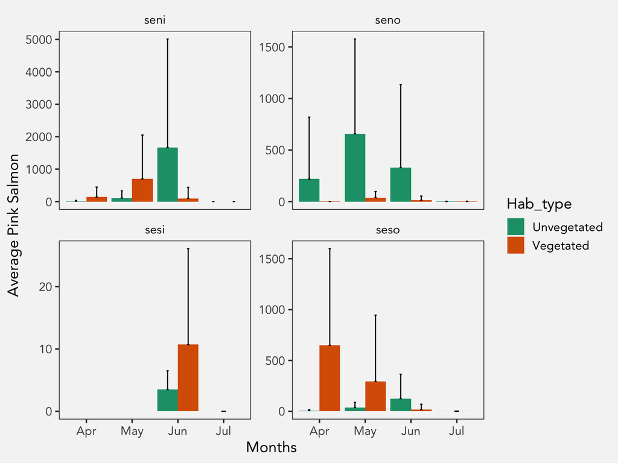

Figure 12: Average (+sd) number of pink salmon caught in summer months in vegetated and unvegetated habitats with free y axis scales across four Southeastern districts excluding Yakutat

### Boxplot version

Lets look at the boxplot version of that

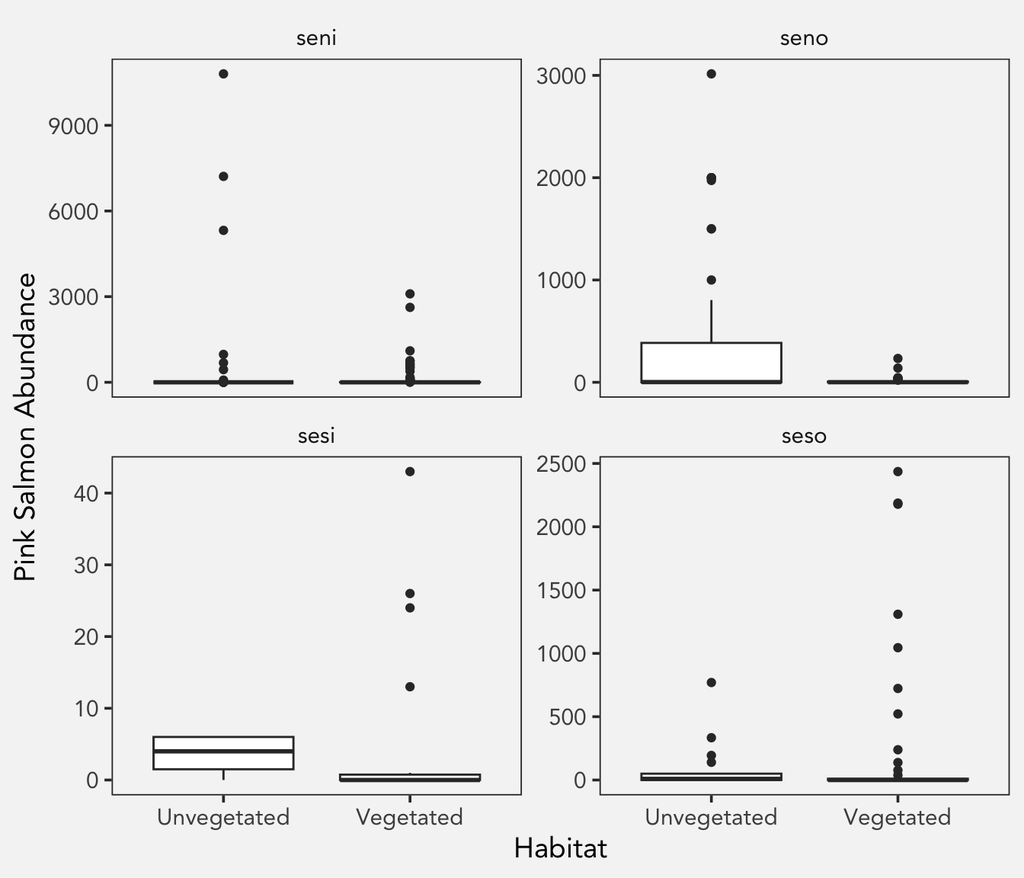

Figure 13: Boxplot of pink salmon abundances across four Southeastern districts excluding Yakutat

Theres so much variability! This graph only includes those same four summer months again.